# Project: Investigate a Dataset - Tmdb Movies

- Introduction
- Data Wrangling
- Exploratory Data Analysis
- Conclusions

## Introduction

### Dataset Description

#### This data set contains information about 10,000 movies collected from The Movie Database (TMDb), including user ratings and revenue.

### Question(s) for Analysis

Question 1: Does the budget determine the profit?

Question 2: Which attributes have the most strong relationship with revenue?

Question 3: Which are the most popular movie genres?

Question 4: Which period produced many movies?

```python
#importing packages

import pandas as pd
import numpy as np
import matplotlib.pyplot as plt
import seaborn as sns
% matplotlib inline
```

```python
# Upgrade pandas to use dataframe.explode() function.
!pip install --upgrade pandas==0.25.0
```

## Data Wrangling

Loading data and checking for its cleanliness as well as removing all unnecessary data that is not going to be used for analysis

```python
#loading data
movies = pd.read_csv('movies.csv')
```

```python
#showing top 5 rows from the dataset
movies.head()
```

|  | id | imdb_id | popularity | budget | revenue | original_title | cast | homepage | director | tagline | ... | overview | runtime | genres | production_companies | release_date | vote_count | vote_average | release_year | budget_adj | revenue_adj |
| --- | --- | --- | --- | --- | --- | --- | --- | --- | --- | --- | --- | --- | --- | --- | --- | --- | --- | --- | --- | --- | --- |
| 0 | 135397 | tt0369610 | 32.985763 | 150000000 | 1513528810 | Jurassic World | Chris Pratt\|Bryce Dallas Howard\|Irrfan Khan\|Vi... | http://www.jurassicworld.com/ | Colin Trevorrow | The park is open. | ... | Twenty-two years after the events of Jurassic ... | 124 | Action\|Adventure\|Science Fiction\|Thriller | Universal Studios\|Amblin Entertainment\|Legenda... | 6/9/15 | 5562 | 6.5 | 2015 | 1.379999e+08 | 1.392446e+09 |
| 1 | 76341 | tt1392190 | 28.419936 | 150000000 | 378436354 | Mad Max: Fury Road | Tom Hardy\|Charlize Theron\|Hugh Keays-Byrne\|Nic... | http://www.madmaxmovie.com/ | George Miller | What a Lovely Day. | ... | An apocalyptic story set in the furthest reach... | 120 | Action\|Adventure\|Science Fiction\|Thriller | Village Roadshow Pictures\|Kennedy Miller Produ... | 5/13/15 | 6185 | 7.1 | 2015 | 1.379999e+08 | 3.481613e+08 |
| 2 | 262500 | tt2908446 | 13.112507 | 110000000 | 295238201 | Insurgent | Shailene Woodley\|Theo James\|Kate Winslet\|Ansel... | http://www.thedivergentseries.movie/#insurgent | Robert Schwentke | One Choice Can Destroy You | ... | Beatrice Prior must confront her inner demons ... | 119 | Adventure\|Science Fiction\|Thriller | Summit Entertainment\|Mandeville Films\|Red Wago... | 3/18/15 | 2480 | 6.3 | 2015 | 1.012000e+08 | 2.716190e+08 |
| 3 | 140607 | tt2488496 | 11.173104 | 200000000 | 2068178225 | Star Wars: The Force Awakens | Harrison Ford\|Mark Hamill\|Carrie Fisher\|Adam D... | http://www.starwars.com/films/star-wars-episod... | J.J. Abrams | Every generation has a story. | ... | Thirty years after defeating the Galactic Empi... | 136 | Action\|Adventure\|Science Fiction\|Fantasy | Lucasfilm\|Truenorth Productions\|Bad Robot | 12/15/15 | 5292 | 7.5 | 2015 | 1.839999e+08 | 1.902723e+09 |
| 4 | 168259 | tt2820852 | 9.335014 | 190000000 | 1506249360 | Furious 7 | Vin Diesel\|Paul Walker\|Jason Statham\|Michelle ... | http://www.furious7.com/ | James Wan | Vengeance Hits Home | ... | Deckard Shaw seeks revenge against Dominic Tor... | 137 | Action\|Crime\|Thriller | Universal Pictures\|Original Film\|Media Rights ... | 4/1/15 | 2947 | 7.3 | 2015 | 1.747999e+08 | 1.385749e+09 |

5 rows × 21 columns

```python
movies.corr()
```

|  | id | popularity | budget | revenue | runtime | vote_count | vote_average | release_year | budget_adj | revenue_adj |
| --- | --- | --- | --- | --- | --- | --- | --- | --- | --- | --- |
| id | 1.000000 | -0.014350 | -0.141351 | -0.099227 | -0.088360 | -0.035551 | -0.058363 | 0.511364 | -0.189015 | -0.138477 |
| popularity | -0.014350 | 1.000000 | 0.545472 | 0.663358 | 0.139033 | 0.800828 | 0.209511 | 0.089801 | 0.513550 | 0.609083 |
| budget | -0.141351 | 0.545472 | 1.000000 | 0.734901 | 0.191283 | 0.632702 | 0.081014 | 0.115931 | 0.968963 | 0.622505 |
| revenue | -0.099227 | 0.663358 | 0.734901 | 1.000000 | 0.162838 | 0.791175 | 0.172564 | 0.057048 | 0.706427 | 0.919110 |
| runtime | -0.088360 | 0.139033 | 0.191283 | 0.162838 | 1.000000 | 0.163278 | 0.156835 | -0.117204 | 0.221114 | 0.175676 |
| vote_count | -0.035551 | 0.800828 | 0.632702 | 0.791175 | 0.163278 | 1.000000 | 0.253823 | 0.107948 | 0.587051 | 0.707942 |
| vote_average | -0.058363 | 0.209511 | 0.081014 | 0.172564 | 0.156835 | 0.253823 | 1.000000 | -0.117632 | 0.093039 | 0.193085 |
| release_year | 0.511364 | 0.089801 | 0.115931 | 0.057048 | -0.117204 | 0.107948 | -0.117632 | 1.000000 | 0.016793 | -0.066256 |
| budget_adj | -0.189015 | 0.513550 | 0.968963 | 0.706427 | 0.221114 | 0.587051 | 0.093039 | 0.016793 | 1.000000 | 0.646607 |
| revenue_adj | -0.138477 | 0.609083 | 0.622505 | 0.919110 | 0.175676 | 0.707942 | 0.193085 | -0.066256 | 0.646607 | 1.000000 |

```python
movies.duplicated().sum()
```

```
1
```

```python
movies.isnull().sum()
```

```
id                         0
imdb_id                   10
popularity                 0
budget                     0
revenue                    0
original_title             0
cast                      76
homepage                7930
director                  44
tagline                 2824
keywords                1493
overview                   4
runtime                    0
genres                    23
production_companies    1030
release_date               0
vote_count                 0
vote_average               0
release_year               0
budget_adj                 0
revenue_adj                0
dtype: int64
```

```python
movies.info()
```

```
<class 'pandas.core.frame.DataFrame'>
RangeIndex: 10866 entries, 0 to 10865
Data columns (total 21 columns):
id                      10866 non-null int64
imdb_id                 10856 non-null object
popularity              10866 non-null float64
budget                  10866 non-null int64
revenue                 10866 non-null int64
original_title          10866 non-null object
cast                    10790 non-null object
homepage                2936 non-null object
director                10822 non-null object
tagline                 8042 non-null object
keywords                9373 non-null object
overview                10862 non-null object
runtime                 10866 non-null int64
genres                  10843 non-null object
production_companies    9836 non-null object
release_date            10866 non-null object
vote_count              10866 non-null int64
vote_average            10866 non-null float64
release_year            10866 non-null int64
budget_adj              10866 non-null float64
revenue_adj             10866 non-null float64
dtypes: float64(4), int64(6), object(11)
memory usage: 1.7+ MB
```

### Data Cleaning

Dropped null values because they were not necessary.

Dropped duplicated rows because there was no need to keep it.

Dropped unnecessary columns to reduce the dataset so that it can be easier to work with

```python
#Drop null values
movies.dropna(inplace = True)
movies.reset_index(drop = True, inplace = True)
```

```python
#Droppng duplicates
movies.drop_duplicates(inplace = True)
```

```python
#Deleting unnecessary columns
notused = ['release_date','cast', 'homepage', 'director', 'tagline', 'keywords', 'production_companies']
movies.drop(notused, axis = 1, inplace = True)

movies.head()
```

|  | id | imdb_id | popularity | budget | revenue | original_title | overview | runtime | genres | vote_count | vote_average | release_year | budget_adj | revenue_adj |
| --- | --- | --- | --- | --- | --- | --- | --- | --- | --- | --- | --- | --- | --- | --- |
| 0 | 135397 | tt0369610 | 32.985763 | 150000000 | 1513528810 | Jurassic World | Twenty-two years after the events of Jurassic ... | 124 | Action\|Adventure\|Science Fiction\|Thriller | 5562 | 6.5 | 2015 | 1.379999e+08 | 1.392446e+09 |
| 1 | 76341 | tt1392190 | 28.419936 | 150000000 | 378436354 | Mad Max: Fury Road | An apocalyptic story set in the furthest reach... | 120 | Action\|Adventure\|Science Fiction\|Thriller | 6185 | 7.1 | 2015 | 1.379999e+08 | 3.481613e+08 |
| 2 | 262500 | tt2908446 | 13.112507 | 110000000 | 295238201 | Insurgent | Beatrice Prior must confront her inner demons ... | 119 | Adventure\|Science Fiction\|Thriller | 2480 | 6.3 | 2015 | 1.012000e+08 | 2.716190e+08 |
| 3 | 140607 | tt2488496 | 11.173104 | 200000000 | 2068178225 | Star Wars: The Force Awakens | Thirty years after defeating the Galactic Empi... | 136 | Action\|Adventure\|Science Fiction\|Fantasy | 5292 | 7.5 | 2015 | 1.839999e+08 | 1.902723e+09 |
| 4 | 168259 | tt2820852 | 9.335014 | 190000000 | 1506249360 | Furious 7 | Deckard Shaw seeks revenge against Dominic Tor... | 137 | Action\|Crime\|Thriller | 2947 | 7.3 | 2015 | 1.747999e+08 | 1.385749e+09 |

# Exploratory Data Analysis

### Research Question 1: Does the budget determine the profit?

```python
#Adding the column for profit in the dataset
movies.insert(5, 'profit', movies['revenue'] - movies['budget'])
movies.head(2)
```

|  | id | imdb_id | popularity | budget | revenue | profit | original_title | overview | runtime | genres | vote_count | vote_average | release_year | budget_adj | revenue_adj |
| --- | --- | --- | --- | --- | --- | --- | --- | --- | --- | --- | --- | --- | --- | --- | --- |
| 0 | 135397 | tt0369610 | 32.985763 | 150000000 | 1513528810 | 1363528810 | Jurassic World | Twenty-two years after the events of Jurassic ... | 124 | Action\|Adventure\|Science Fiction\|Thriller | 5562 | 6.5 | 2015 | 1.379999e+08 | 1.392446e+09 |
| 1 | 76341 | tt1392190 | 28.419936 | 150000000 | 378436354 | 228436354 | Mad Max: Fury Road | An apocalyptic story set in the furthest reach... | 120 | Action\|Adventure\|Science Fiction\|Thriller | 6185 | 7.1 | 2015 | 1.379999e+08 | 3.481613e+08 |

```python
#correlationship between budget and profit
movies['budget'].corr(movies['profit'])
```

```
0.6144152428897638
```

The below figure shows the relatioship between budget of the movie and profit, to check if the budget of the movie determines the profit.

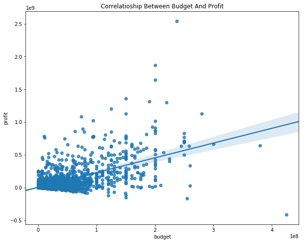

```python
plt.figure(figsize = (10,8))
sns.regplot(x=movies['budget'], y= movies['profit'])
plt.title('Correlatioship Between Budget And Profit')
plt.show()
```

### Research Question 2: Which attributes have the most strong relationship with revenue?

```python
#checking the following attributes if they have any relationship with the revenue
movies[['revenue','popularity','budget','runtime','vote_average']].corr()
```

|  | revenue | popularity | budget | runtime | vote_average |
| --- | --- | --- | --- | --- | --- |
| revenue | 1.000000 | 0.641346 | 0.747273 | 0.257756 | 0.258208 |
| popularity | 0.641346 | 1.000000 | 0.513553 | 0.220787 | 0.298066 |
| budget | 0.747273 | 0.513553 | 1.000000 | 0.269480 | 0.118651 |
| runtime | 0.257756 | 0.220787 | 0.269480 | 1.000000 | 0.243699 |
| vote_average | 0.258208 | 0.298066 | 0.118651 | 0.243699 | 1.000000 |

### Research Question 3: Which are the most popular movie genres?

```python
#Does the director influence the popularity of the movie
def groupGenres(column, dataFrame):
    genres= dataFrame[column].str.cat(sep = '|')
    genres = pd.Series(genres.split('|'))
    groupedByCount = genres.value_counts(ascending = False)
    return groupedByCount
```

```python
#Genre with higest number of movies
genres = groupGenres('genres', movies)

genres.head(10)
```

```
Drama              838
Comedy             640
Thriller           575
Action             532
Adventure          361
Romance            291
Science Fiction    291
Horror             273
Crime              262
Family             233
dtype: int64
```

[figure not shown]

```python
#Bar graph showing the top 10 popular genres
graph = genres.plot.bar( fontsize = 12)
graph.set(title = 'Top 10 popular genres')
graph.set_xlabel('Movie genres', fontsize = '13')
graph.figure.set_size_inches(10, 8)
plt.show()
```

```python
#checking unique years that the movies were produced

movies.release_year.unique()
```

```
array([2015, 2014, 1977, 2009, 2010, 1999, 2001, 2008, 2011, 2002, 1994,
       2012, 2003, 1997, 2013, 1985, 2005, 2006, 2004, 1972, 1980, 2007,
       1979, 1984, 1983, 1995, 1992, 1981, 1996, 2000, 1982, 1998, 1989,
       1991, 1988, 1987, 1974, 1975, 1962, 1964, 1971, 1990, 1961, 1976,
       1993, 1967, 1963, 1986, 1973, 1970, 1965, 1969, 1978])
```

### Research Question 4: Which period produced many movies?

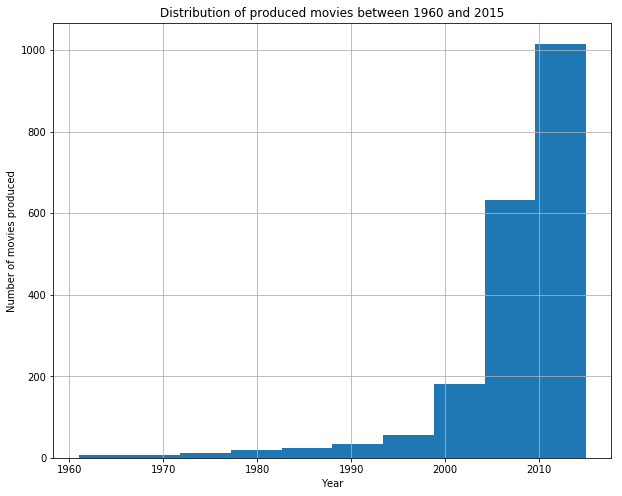

```python
#produced movies over the years

plt.figure(figsize = (10,8))
movies.release_year.hist()
plt.title('Distribution of produced movies between 1960 and 2015')
plt.ylabel('Number of movies produced')
plt.xlabel('Year')
plt.show()
```

## Conclusions

#### Does the budget determine the profit?

It shows that in most cases budget determines the profit since there is positive fair relationship as shown on the scatterplot.

#### Which attributes had the most strong relationship with revenue?

Popularity and budget had the strongest positive relationship with revenue.

#### Which are the most popular movie genres?

Drama is the most popular genre followed by comedy.

## Limitations

i colud not check how long it takes to produce a movie on average since the dataset only showed the release date and year but not stating when the production started

```python
from subprocess import call
call(['python', '-m', 'nbconvert', 'Investigate_a_Dataset.ipynb'])
```

```
0
```